# Danish Kings

Terkel Sylvester

2026-03-12

## Load the kings

The separators in my csv `kongeraekken.csv` are semicolons!

2. Create a `kings` object in R with the different functions below and inspect the different outputs.
- `read.csv()`
- `read_csv()`
- `read.csv2()`
- `read_csv2()`

```r
library(tidyverse)
kings1 <- read.csv("data/kongeraekke.csv")

kings2 <- read_csv("data/kongeraekke.csv")
kings3 <- read.csv2("data/kongeraekke.csv")

kings4 <- read_csv2( "data/kongeraekke.csv") # this one works ! it makes the numbers numbers and the characters characters
```

```
## ℹ Using "','" as decimal and "'.'" as grouping mark. Use `read_delim()` for more control.
```

Answer:

1. Which of these functions is a `tidyverse` function?

the tidyverse functions are read_csv and read_csv2

2. What is the result of running `class()` on the `kings` object created with a tidyverse function.

“spec_tbl_df” “tbl_df” “tbl” “data.frame”

3. How many columns does the object have when created with these different functions?

read.csv and read_csv both have one column, and both read.csv2 and read_csv2 have 8 columns, but read.csv2 makes “int”-classed columns rather than “num”-classed (as with read_csv2)

4. Show the dataset so that we can see how R interprets each column

```r
kings <- read_csv2( "data/kongeraekke.csv")
```

```
## ℹ Using "','" as decimal and "'.'" as grouping mark. Use `read_delim()` for more control.
```

```r
class(kings)
```

```
## [1] "spec_tbl_df" "tbl_df"      "tbl"         "data.frame"
```

```r
ncol(kings)
```

```
## [1] 8
```

```r
glimpse(kings)
```

```
## Rows: 57
## Columns: 8
## $ number       <dbl> 1, 2, 3, 4, 5, 6, 7, 8, 9, 10, 11, 12, 13, 14, 15, 16, 17…
## $ name         <chr> "Gorm den Gamle", "Harald Blaatand", "Svend Tveskaeg", "H…
## $ birth_year   <dbl> NA, NA, 963, NA, 995, 1020, 1027, 1020, 1040, 1042, 1050,…
## $ death_year   <dbl> 958, 987, 1014, 1018, 1035, 1042, 1047, 1076, 1080, 1086,…
## $ life_length  <dbl> NA, NA, 51, NA, 40, 22, 20, 56, 40, 44, 45, 47, 69, 47, N…
## $ reign_start  <dbl> 936, 958, 987, 1014, 1018, 1035, 1042, 1047, 1076, 1080, …
## $ reign_end    <dbl> 958, 987, 1014, 1018, 1035, 1042, 1047, 1076, 1080, 1086,…
## $ reign_length <dbl> 22, 29, 27, 4, 17, 7, 5, 29, 4, 6, 9, 8, 30, 3, 9, 11, 11…
```

## Calculate the duration of reign for all the kings in your table

You can calculate the duration of reign in years with `mutate` function by subtracting the equivalents of your `startReign` from `endReign` columns and writing the result to a new column called `duration`.

```r
kings <- kings %>%
  mutate(duration = reign_end - reign_start) %>%
  arrange(desc(duration))
```

## Calculate the average duration of reign for all rulers

```r
# i have three ways of selecting the duration column:
mean(kings[["duration"]], na.rm=TRUE)
```

```
## [1] 19.76786
```

```r
mean(kings$duration, na.rm=TRUE)
```

```
## [1] 19.76786
```

```r
# both of these functions turn the column into a vector

kings %>%
  summarize(mean_duration = mean(duration, na.rm=TRUE))
```

```
## # A tibble: 1 × 1
##   mean_duration
##           <dbl>
## 1          19.8
```

```r
# this instead works on a tibble
```

## How many and which kings enjoyed a longer-than-average duration of reign?

```r
# creating a new tibble only including kings who reigned for a longer-than-average time:
longer_than_avg <- kings %>%
  filter(duration>19.7)

head(longer_than_avg)
```

```
## # A tibble: 6 × 9
##   number name            birth_year death_year life_length reign_start reign_end
##    <dbl> <chr>                <dbl>      <dbl>       <dbl>       <dbl>     <dbl>
## 1     42 Christian 4.          1577       1648          71        1588      1648
## 2     56 Margrethe 2.          1940         NA          NA        1972      2024
## 3     52 Christian 9.          1818       1906          88        1863      1906
## 4     48 Christian 7.          1749       1808          59        1766      1808
## 5     20 Valdemar Sejr         1170       1241          71        1202      1241
## 6     18 Valdemar den S…       1131       1182          51        1146      1182
## # ℹ 2 more variables: reign_length <dbl>, duration <dbl>
```

```r
nrow(longer_than_avg) # returns 28, showing that there have been 28 kings with an above-average reign duration
```

```
## [1] 28
```

## How many days did the three longest-ruling monarchs rule?

```r
top_three <- kings %>%
  arrange(desc(duration)) %>%
  slice_head(n=3) %>%
  mutate(Days = duration*365) %>%
  select(name, duration, Days)

head(top_three)
```

```
## # A tibble: 3 × 3
##   name         duration  Days
##   <chr>           <dbl> <dbl>
## 1 Christian 4.       60 21900
## 2 Margrethe 2.       52 18980
## 3 Christian 9.       43 15695
```

## Challenge: Plot the kings’ duration of reign through time

What is the long-term trend in the duration of reign among Danish monarchs? How does it relate to the historical violence trends ?

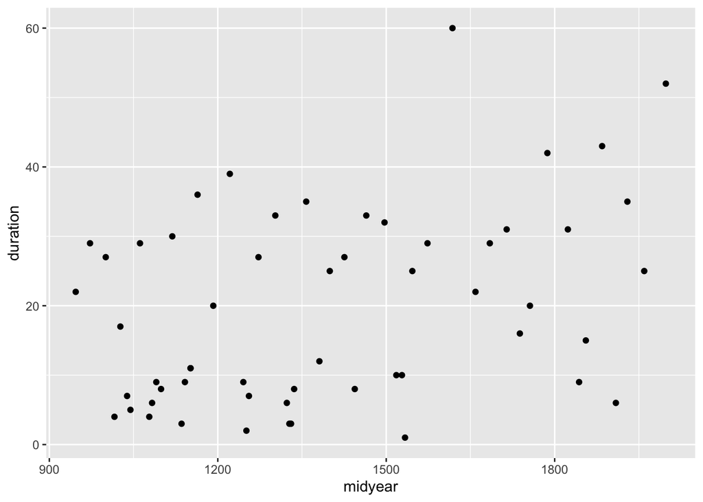

```r
# first, we add a midyear-column (for plotting to the x-axis)
kings <- kings %>%
  mutate(midyear = reign_start + (reign_end-reign_start)/2)

kings %>%
  ggplot(aes(x = midyear, y = duration)) +
  geom_point()
```

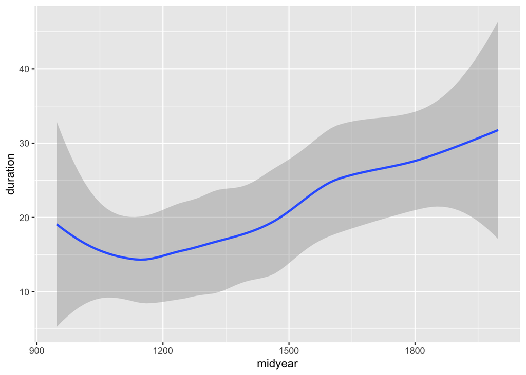

```r
# shows that reigns are generally longer later, but very scattered indeed

kings %>%
  ggplot(aes(x = midyear, y = duration)) +
  geom_smooth()
```

```r
# more of a big picture-visualisation: Christian 4.s 60 year long reign, while obvious in the above geom_point()-visualisation, has here very little effect
```